# Primary Human Hepatocytes baseline description by scRNAseq

Enrique M. Toledo

26/02/2020

**scPPIN input Generation**

This file shows a reproducible code of the single cell RNA seq procedure to generate the input for scPPIN used in the manuscript Klimm F et al.

Details : https://github.com/floklimm/scPPIN

> Functional module detection through integration of single-cell RNA sequencing data with protein–protein interaction networks.  
> Florian Klimm, Enrique M. Toledo, Thomas Monfeuga, Fang Zhang, Charlotte M. Deane, and Gesine Reinert  
> bioRxiv 698647; doi: https://doi.org/10.1101/698647

## Data Loading from GEO

Getting the dataset from GEO, accession GSE133948. This notebook was done with Seurat version 2, to install it please follow the instructions from [here](https://satijalab.org/seurat/install.html)

```r
suppressMessages(library(tidyverse))
suppressMessages(library(cowplot))
#source("https://z.umn.edu/archived-seurat") # to install v2
suppressMessages(library(Seurat))
```

```r
if (packageVersion("Seurat")!='2.3.4'){ stop("Please install Seurat v2. Instructions here: https://satijalab.org/seurat/install.html")}
# Get data from https://www.ncbi.nlm.nih.gov/geo/query/acc.cgi?acc=GSE133948
counts <- read_csv("ftp://ftp.ncbi.nlm.nih.gov/geo/series/GSE133nnn/GSE133948/suppl/GSE133948_Raw.counts_baseline_liverspheroid.csv.gz") %>% rename(SYMBOL=X1)
metadata <- read_csv("ftp://ftp.ncbi.nlm.nih.gov/geo/series/GSE133nnn/GSE133948/suppl/GSE133948_metadata_cells.csv.gz")
```

## Reconstruct Seurat Object

The information of on which sequencing run/lane was not included in GEO metadata althoug it can be extracted from biosamples information. But now it is available in here in file `cell_run_info.rds` in here.

Details https://www.ncbi.nlm.nih.gov/sra?LinkName=biosample_sra&from_uid=12231096

```r
# Separate cells by sequencing runs
runs_info <- read_rds("cell_run_info.rds")

# duplicated(runs_info$barcode) %>% table() #sanity check

run1.id <- runs_info %>% filter(run==1) %>% pull(barcode) #GSM3930530
run2.id <- runs_info %>% filter(run==2) %>% pull(barcode) #GSM3930531

run1 <- select(counts,SYMBOL,!!run1.id) %>% column_to_rownames("SYMBOL") %>% as.data.frame()
run2 <- select(counts,SYMBOL,!!run2.id) %>% column_to_rownames("SYMBOL") %>% as.data.frame()

# create seurat v2 objects and normalize
run1 <- CreateSeuratObject(run1,min.features = 500)
run1 <- NormalizeData(run1)
run1 <- FilterCells(run1, subset.names = "nGene", low.thresholds = 500, high.thresholds = 6000)
run1 <- ScaleData(run1, display.progress = F)
run1 <- FindVariableGenes(run1,do.plot = F)

run2 <- CreateSeuratObject(run2)
run2 <- FilterCells(run2, subset.names = "nGene", low.thresholds = 500, high.thresholds = 6000)
run2 <- NormalizeData(run2)
run2 <- ScaleData(run2, display.progress = F)
run2 <- FindVariableGenes(run2,do.plot = F)


# CCA Data aligment
genes.use <- unique(c(head(rownames(run1@hvg.info), 2000),
                      head(rownames(run2@hvg.info), 2000)))

run1@meta.data$run <- "run_1"
run2@meta.data$run <- "run_2"

# Add treatment to metadata
run1@meta.data$treatment <- "BS" #for baseline
run2@meta.data$treatment <- "BS"

# Run CCA
BS.spheroid <- RunCCA(object= run1,object2 = run2, genes.use = genes.use)

# MetageneBicorPlot(BS.spheroid, grouping.var = "run", dims.eval = 1:20, display.progress = F)

# Align the CCA subspaces
BS.spheroid <- AlignSubspace(BS.spheroid, reduction.type = "cca", grouping.var = "run", dims.align = 1:9)

rm(run1,run2,run1.id,run2.id,runs_info,genes.use)#clean stuff
```

## Add metadata - cell identity to clusters

Cluster identity was done with public data (Bader 2018, Grun 2019, Henderson 2019).

Bader dataset 2018 (this one describes liver cell types specific markers in figure 2.d):  
Paper: https://www.nature.com/articles/s41467-018-06318-7  
GEO: https://www.ncbi.nlm.nih.gov/geo/query/acc.cgi?acc=GSE115469  
Github: https://github.com/BaderLab/HumanLiver

Grun dataset 2019:  
Paper: https://www.nature.com/articles/s41586-019-1373-2  
GEO: https://www.ncbi.nlm.nih.gov/geo/query/acc.cgi?acc=GSE124395  
Interactive map: http://human-liver-cell-atlas.ie-freiburg.mpg.de/

Henderson dataset 2019 (Fibrotic niche):  
Paper: https://www.nature.com/articles/s41586-019-1631-3  
GEO: https://www.ncbi.nlm.nih.gov/geo/query/acc.cgi?acc=GSE136103  
Interactive map: http://www.livercellatlas.mvm.ed.ac.uk//

```r
#BS.spheroid@meta.data$cell.type <- NULL

cell.type <- data.frame(res.1=as.character(0:9),cell.type=c(rep("hepatocyte",4),"macrophage",rep("hepatocyte",3),"cholangiocytes","stellated"))

cell.type_id <- BS.spheroid@meta.data %>% left_join(cell.type,by="res.1") #%>% dplyr::select(cell.type)
rownames(cell.type_id) <- rownames(BS.spheroid@meta.data)


# AddMetaData adds columns to object@meta.data, and is a great place to
BS.spheroid <- AddMetaData(object = BS.spheroid, metadata = cell.type_id, col.name = "cell.type")

cell.type %>% rename(Cluster=res.1,"Cell type"=cell.type) %>% knitr::kable()
```

| Cluster | Cell type |
| --- | --- |
| 0 | hepatocyte |
| 1 | hepatocyte |
| 2 | hepatocyte |
| 3 | hepatocyte |
| 4 | macrophage |
| 5 | hepatocyte |
| 6 | hepatocyte |
| 7 | hepatocyte |
| 8 | cholangiocytes |
| 9 | stellated |

### tSNE plots by cell type and clusters

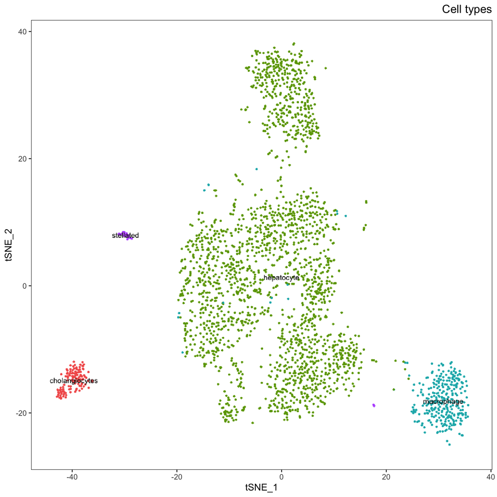

```r
DimPlot(object = BS.spheroid, reduction.use = "tsne", no.legend = T,do.label = T, do.return = TRUE,
              vector.friendly = TRUE, pt.size = 1,group.by = "cell.type") + ggtitle("Cell types") +
  theme(plot.title = element_text(hjust = 1))
```

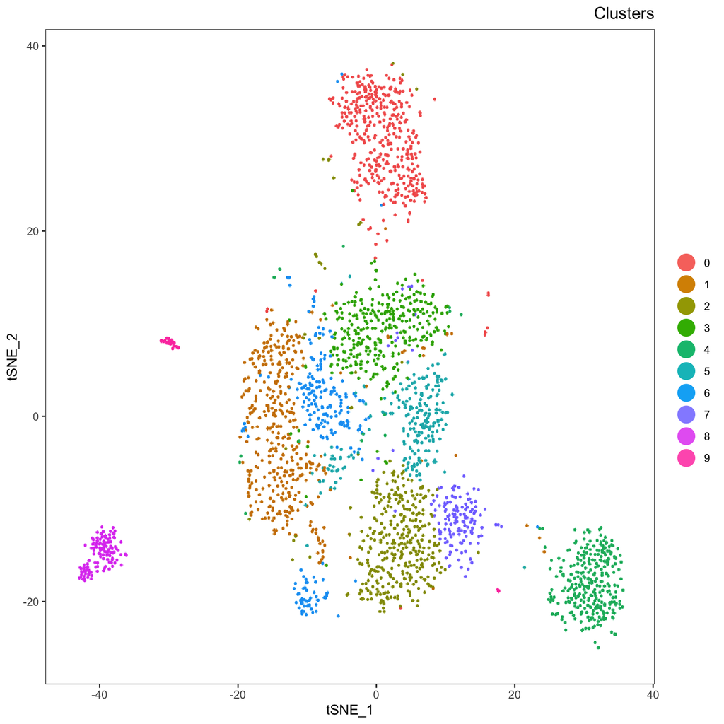

```r
DimPlot(object = BS.spheroid, reduction.use = "tsne", no.legend = F, do.return = TRUE,
              vector.friendly = TRUE, pt.size = 1) + ggtitle("Clusters") +
  theme(plot.title = element_text(hjust = 1))
```

### Example gene expression

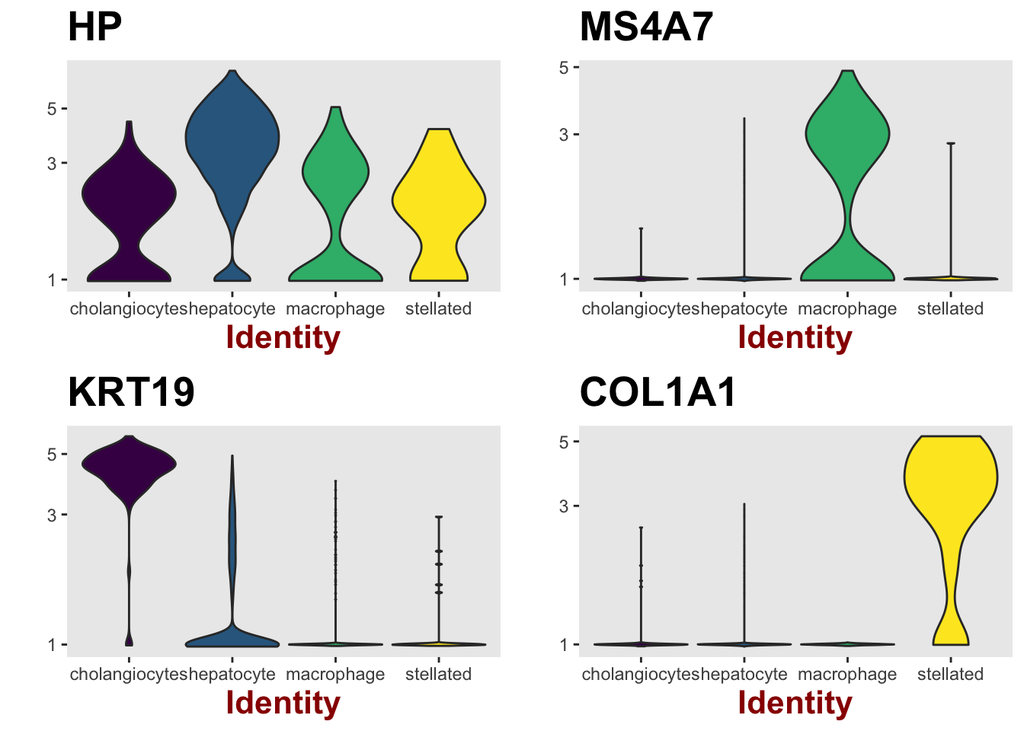

```r
# VlnPlot(object = BS.spheroid, features.plot = "HP",group.by = "ident", point.size.use = 0,do.return = T,y.log = T) + theme_classic() + theme(legend.position = "none")
# VlnPlot(object = BS.spheroid, features.plot = "MS4A7",group.by = "ident", point.size.use = 0,do.return = T,y.log = T) + theme_classic() + theme(legend.position = "none")
# VlnPlot(object = BS.spheroid, features.plot = "KRT19",group.by = "ident", point.size.use = 0,do.return = T,y.log = T) + theme_classic() + theme(legend.position = "none")
# VlnPlot(object = BS.spheroid, features.plot = "COL1A1",group.by = "ident", point.size.use = 0,do.return = T,y.log = T) + theme_classic() + theme(legend.position = "none")

VlnPlot(object = BS.spheroid, features.plot = c("HP","MS4A7","KRT19","COL1A1"),
        group.by = "cell.type", point.size.use = 0,do.return = T,y.log = T,nCol = 2,cols.use = scales::viridis_pal()(4))
```

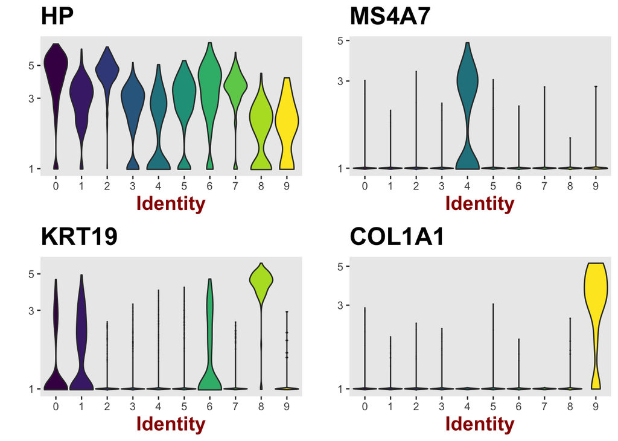

```r
VlnPlot(object = BS.spheroid, features.plot = c("HP","MS4A7","KRT19","COL1A1"),
        point.size.use = 0,do.return = T,y.log = T,nCol = 2,cols.use = scales::viridis_pal()(10))
```

## Gene markers identification for scPPIN

As described in manuscript, this was done without filtering, therefore this step it does take some time to run (~45 min in a 2017 ok machine)

```r
#only hepatocytes
genes.per.cluster.bs_nofilter <- FindAllMarkers(object = BS.spheroid,print.bar = F,random.seed = 12345,logfc.threshold=0.0,return.thresh = 1)
write_rds(genes.per.cluster.bs_nofilter,path = "genes.per.cluster.bs_nofilter_20190423.RDS",compress = "xz")
```

```r
genes.per.cluster.bs_nofilter <- read_rds("genes.per.cluster.bs_nofilter_20190423.RDS") %>% as_tibble()
genes.per.cluster.bs_nofilter
```

```
## # A tibble: 59,788 x 7
##        p_val avg_logFC pct.1 pct.2 p_val_adj cluster gene
##        <dbl>     <dbl> <dbl> <dbl>     <dbl> <fct>   <chr>
##  1 9.17e-209     -1.57 0.822 0.997 1.41e-204 0       RPS12
##  2 5.49e-208     -2.22 0.971 1     8.43e-204 0       FTH1
##  3 1.63e-207     -1.45 0.898 0.999 2.50e-203 0       RPL13A
##  4 1.13e-205     -1.41 0.966 1     1.74e-201 0       RPL41
##  5 6.52e-203     -1.40 0.876 0.999 1.00e-198 0       RPL13
##  6 6.52e-200     -1.44 0.776 0.997 1.00e-195 0       RPLP2
##  7 1.54e-199     -1.46 0.834 0.996 2.37e-195 0       RPS14
##  8 1.40e-198     -1.47 0.793 0.996 2.14e-194 0       RPL32
##  9 1.98e-197     -1.48 0.783 0.994 3.03e-193 0       RPL23A
## 10 3.17e-197     -1.47 0.79  0.995 4.86e-193 0       RPL27A
## # … with 59,778 more rows
```

```r
genes.per.cluster.bs_nofilter %>% filter(p_val_adj<=0.05) %>% group_by(cluster) %>% inner_join(cell.type,by=c("cluster"="res.1")) %>% count(cell.type) %>% rename("Number of DEG genes (Adj p-val <= 0.05)"=n)
```

```
## # A tibble: 10 x 3
## # Groups:   cluster [10]
##    cluster cell.type      `Number of DEG genes (Adj p-val <= 0.05)`
##    <fct>   <fct>                                              <int>
##  1 0       hepatocyte                                          1749
##  2 1       hepatocyte                                          3331
##  3 2       hepatocyte                                           737
##  4 3       hepatocyte                                           635
##  5 4       macrophage                                          2379
##  6 5       hepatocyte                                           577
##  7 6       hepatocyte                                           876
##  8 7       hepatocyte                                           497
##  9 8       cholangiocytes                                      1937
## 10 9       stellated                                            654
```

### Description of output of DEG per cluster

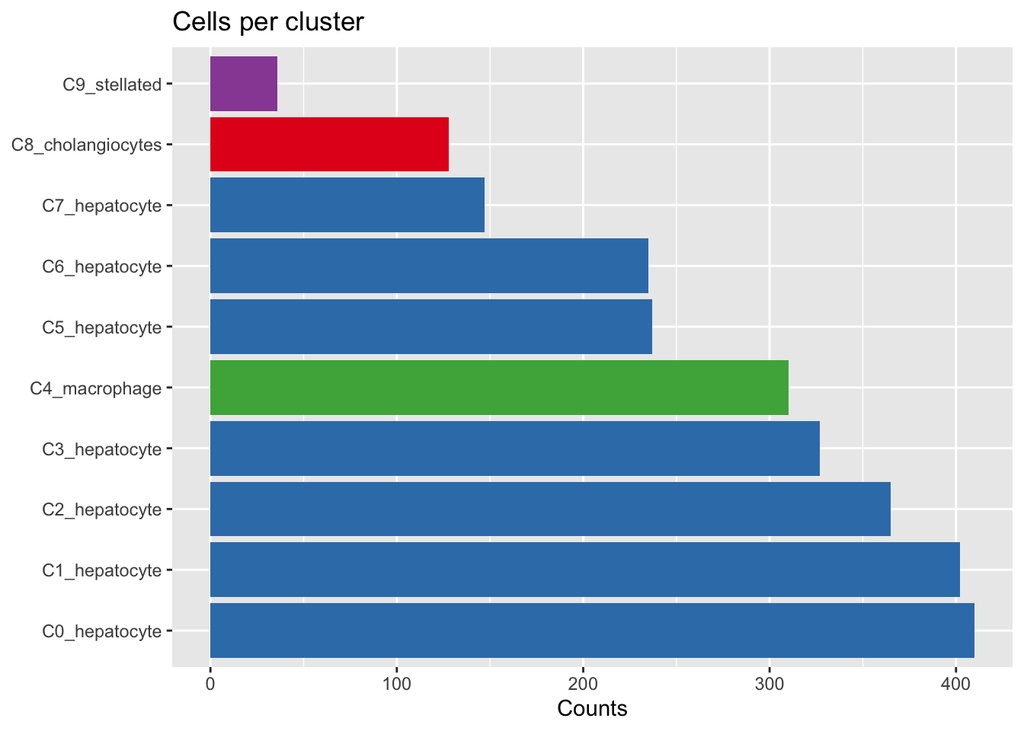

```r
metadata %>% count(cluster_id,cell.type) %>% arrange(-n) %>% mutate(label=paste0("C",cluster_id,"_",cell.type)) %>%
  ggplot(aes(x=label,n,fill=cell.type))+geom_bar(stat = "identity",show.legend = F) + labs(x=NULL,y="Counts") + coord_flip() +
  scale_fill_manual(values = scales::brewer_pal(palette = "Set1")(4)) + ggtitle("Cells per cluster")
```

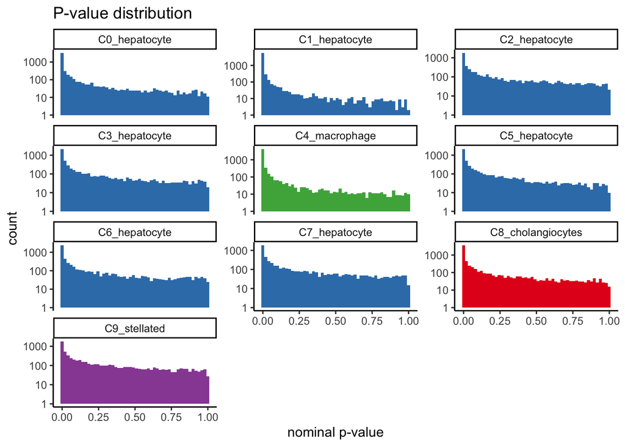

```r
cell.labels <- metadata %>% count(cluster_id,cell.type) %>% arrange(-n) %>% mutate(label=paste0("C",cluster_id,"_",cell.type),
                                                                                   cluster_id=as.character(cluster_id)) %>%
  rename(cluster=cluster_id)


left_join(genes.per.cluster.bs_nofilter,cell.labels,by="cluster") %>%
  ggplot(aes(p_val,fill=cell.type)) + geom_histogram(bins = 50) + facet_wrap(~label,scales = "free_y",ncol = 3) +
  scale_y_log10() + labs(title = "P-value distribution",x="nominal p-value",y="count") + theme_classic() +
  scale_fill_manual(values = scales::brewer_pal(palette = "Set1")(4)) + theme(legend.position = "none")
```